# **MAGLEV Simulação**

Yuri Cota

2023-03-11

# **1. INTRODUÇÃO**

Os ambientes virtuais são ferramentas cada vez mais utilizadas no ensino da engenharia, trazendo diversos benefícios para os estudantes e professores. Eles permitem simulações e experimentações que, muitas vezes, não seriam possíveis em um ambiente físico, além de possibilitar a conexão com alunos e professores de diversas partes do mundo. Neste trabalho, vamos apresentar a simulação do levitador magnético, um dispositivo que utiliza campos magnéticos para levitar objetos, através da ferramenta computacional Python. Além de apresentar o comportamento do levitador, também abordaremos as principais aplicações dessa tecnologia e suas vantagens em relação a outros métodos de levitação, como os baseados em ar comprimido ou forças mecânicas.

A modelagem do levitador magnético pode ser feita através de uma abordagem de espaço de estados, que é uma técnica matemática utilizada para representar sistemas dinâmicos em termos de variáveis de estado e entradas. Esta foi a técnica utilizada no trabalho, e com ela é possível descrever as dinâmicas do sistema em termos de equações diferenciais lineares e obter uma representação matricial do modelo. Também exploraremos os princípios físicos por trás do levitador magnético, incluindo a lei de Faraday, a lei de Lenz e o efeito Meissner, entre outros. A compreensão desses princípios é fundamental para entender como o levitador funciona e como ele pode ser aplicado em diversas áreas, como na indústria automotiva, na medicina e na pesquisa científica.

Por fim, discutiremos algumas limitações e desafios associados ao uso do levitador magnético, bem como possíveis soluções para superá-los. Com isso, esperamos que os alunos possam ter uma visão mais completa e crítica dessa tecnologia e possam aplicá-la de forma eficaz em suas futuras carreiras na engenharia.

# **2. REFERENCIAL TÉORICO**

## **2.1 Diagrama de forças**

A modelagem do levitador magnético é baseada nas leis da dinâmica e requer uma análise cuidadosa dos sistemas de força que atuam sobre o corpo. Identificar as forças aplicadas é fundamental para a modelagem, reduzindo-se o sistema ao centro de massa do corpo e simplificando a análise de suas equações de movimento.

Este sistema apresenta um grau de liberdade, movimentando-se apenas na direção vertical. Suas equações dinâmicas são determinadas a partir da aplicação da segunda lei de Newton ao sistema de forças, o que resulta em um conjunto de equações que possibilita estabelecer o comportamento dinâmico do sistema, conforme a Figura 1.

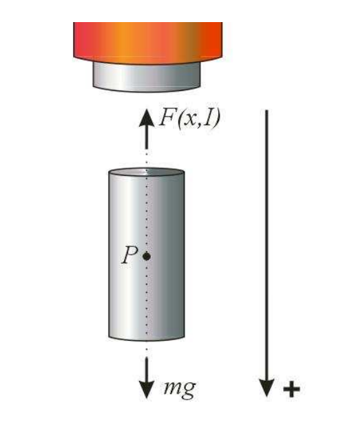

**Figura 1:** Diagrama de forças do sistema.

Um ponto importante é que o modelo é dito geral sob a ótica de não especificar uma função para a força magnética. Sua determinação pode ser dividida em duas etapas: a análise do diagrama de forças do sistema e a análise da força magnética. É necessário entender como a força magnética interage com as outras forças do sistema para conseguir um modelo completo e preciso. A Equação 2.1 resulta da análise do sistema de forças, por convenção o tempo $t$ será omitido da equação.

$$\begin{align*}
m\ddot{x}&=mg-F(x,I)
\end{align*}$$

**Equação 2.1**

Onde:

- $m$ é massa do corpo;
- $\ddot{x}$ é a derivada segunda em relação a $t$;
- $g$ é a aceleração da gravidade;
- $F(x,I)$ é a força de interação magnética entre o imã e a massa, função da distância $x$ e da intensidade de corrente elétrica $I$.

Através da inclusão da variável velocidade $v$ podemos dividir a Equação 1 em duas equações de primeira ordem, obtendo assim a Equação 2.2 e Equação 2.3.

$$\begin{align*}
\dot{x}&=v \\
\dot{v}&=g-\dfrac{F(x,I)}{m}
\end{align*}$$

**Equação 2.2 e 2.3**

Estas equações descrevem o modelo, em variáveis de estado, do processo MAGLEV.

## **2.2 Força magnética**

A formulação clássica para forças magnéticas é dada pela Equação 2.4, entretanto ela possui limitações, pois quando $x \rightarrow 0 \Rightarrow F(x,I) \rightarrow \infty$, que não pode ser observado na prática.

$$\begin{align*}
F(x,I)&=k\dfrac{I^2}{x^2}
\end{align*}$$

**Equação 2.4**

É proposta em [15] a utilização da Equação 2.5 para a função $F(x,I)$.

$$\begin{align*}
F(x,I)=kI^2 e^{-x/a}
\end{align*}$$

**Equação 2.5**

Outra forma adequada é dada pela Equação 2.6, que é apresentada em [57].

$$\begin{align*}
F(x,I)=k\dfrac{I^2}{(x+\mu)^2}
\end{align*}$$

**Equação 2.6**

Onde as constantes $k$ e $\mu$ são características da interação entre o corpo e a bobina. A Equação 5 satisfaz as observaçoes do sistema real, pois a magnitude da força magnética cresce com o aumento da corrente elética, portanto $\partial F/\partial I>0$, e diminuido a medida que o corpo se afasta, admitindo $\partial F/\partial x <0$. Contudo, a Equação 5 é de melhor utilizada na prática, pelo fato da força magnética ser finita para $x=0$.

## **2.3 Ponto de equilíbrio**

Na análise de um sistema dinâmico, é importante identificar seus pontos de equilíbrio, como em estudos de bifurcação e caos [43].

O equilíbrio de um sistema dinâmico, descrito pela equação de estados $\mathbf{\dot{y}=G(y, u)}$, é definido pelos valores $y_0$ e $u_0$ que satisfazem $\dot{y}= 0 = G(y_0,u_0)$, em que: $\mathbf{y} \in R^n$e $\mathbf{u} \in R^p$ (sendo u a entrada do sistema). Ou seja, são pontos cujos valores das variáveis de estado e entrada anulam a dinâmica do sistema. Aplicando esta condição a Equação 2.2 e a Equação 2.3, que se refere as equações de estado do sistema, temos:

$$\begin{align*}
\dot{x}=v_0=0
\end{align*}$$

**Equação 2.7**

Que coincide com a teoria estudada, pois em equilíbrio o corpo estará em repouso. Para a Equação 2.3:

$$\begin{align*}
\dot{v}=g-\dfrac{F(x_0,I_0)}{m}=0\Rightarrow F(x_0,I_0)=mg
\end{align*}$$

Demonstrando que o equilíbrio do sistema ocorre quando a força peso se iguala a força magnética, para um determinado ponto de operação ($x_0,I_0$). Substituindo a Equação 2.6 na Equação 2.3, podemos achar a corrente de equilíbrio $I_0$ ou posição de equilíbrio do sistema $x_0$.

**Equação 2.8**

## **2.4 Linearização do sistema MAGLEV**

A linearização é feita através da expansão em série de Taylor [46] dos termos não-lineares da equação diferencial $\mathbf{\dot{y} = G(y,u)}$ em torno do ponto de operação. A Equação 2.9 apresenta uma forma generalizada para a série de Taylor de uma função vetorial. Para se obter a aproximação linear trunca-se a série no segundo termo.

$$\begin{align*}
\mathbf{G(y,u)=G(y_0,u_0)+\dfrac{\partial G}{\partial
y}(y-y_0)+\dfrac{\partial G}{\partial u}(u-u_0)+\delta}
\end{align*}$$

**Equação 2.9**

Se for desprezada a influência dos termos de ordem superior, $\delta$, pode-se aproximar a equação não-linear $\mathbf{G(y,u)}$ pela Equação 2.10.

$$\begin{align*}
\mathbf{\Delta G(y,u) = A\Delta y +B\Delta u}
\end{align*}$$

**Equação 2.10**

Onde:

$$\begin{align*}
\mathbf{\Delta G(y,u)} &= \mathbf{G(y,u) - G(y_0,u_0)}\\
\mathbf{\Delta y} &= \mathbf{y-y_0}\\
\mathbf{\Delta u} &= \mathbf{u-u_0}\\
\mathbf{A} &= \mathbf{\left.\dfrac{\partial G}{\partial
y}\right|_{y=y_0, u=u_0}}\\
\mathbf{B} &= \mathbf{\left.\dfrac{\partial G}{\partial
u}\right|_{y=y_0, u=u_0}}
\end{align*}$$

**Equação 2.11, 2.12, 2.13, 2.14, 2.15**

Onde os termos $\mathbf{A}$ e $\mathbf{B}$ da Equação 2.11, 2.14 e 2.15, são geralmente utilizados para determinar os estados de um sistema linear invariante no tempo [46]. A notação $\mathbf{\partial G / \partial y}$ significa matriz jacobiana.

Empregando a série de Taylor ao modelo do MAGLEV na Equação 2.2 e 2.3, e admitindo $(x_0,I_0)$ como valores de equilíbrio de posição e corrente, obtém-se:

$$\begin{align*}
\Delta \dot{x} &= \Delta v\\
\Delta \dot{v} &= \lambda^2 \Delta x +k_0 \Delta I
\end{align*}$$

**Equação 2.16, 2.17**

Em que $\lambda$ e $k_0$ foram adotados apenas como forma de simplificar a Equação 2.17, de modo que o termo quadrático ($\lambda^2$) surge após as interações das derivadas quando se lineariza a Equação 2.3, onde:

$$\begin{align*}
\lambda^2 &= -\dfrac{1}{m}\dfrac{\partial F(x_0, I_0)}{\partial x}\\
k_0 &= -\dfrac{1}{m}\dfrac{\partial F(x_0, I_0)}{\partial I}
\end{align*}$$

**Equação 2.18, 2.19**

As Equações 2.16 e 2.17, são equações de estado linearizadas do sistema MAGLEV em torno do ponto de operação (x_0,I_0). Através delas é possível obter a função de transferência, analisar estabilidade e projetar controladores.

## **2.5 Função de Transferência**

A função de transferência de um sistema representado por uma equação diferencial linear invariante no tempo é definida como a relação entre a transformada de Laplace da saída e a transformada de Laplace da entrada, admitindo-se todas as condições iniciais nulas [46, 45].

Dessa forma, aplicando a transformada de Laplace a Equação 2.16 e Equação 2.17:

$$\begin{align*}
s\Delta X(s) &= \Delta V(s)\\
s \Delta V(s) &= \lambda^2 \Delta X(s)+k_0 \Delta I(s)\\
\dfrac{\Delta X(s)}{\Delta I(s)} &=\dfrac{k_0}{s^2-\lambda^2}
\end{align*}$$

**Equação 2.20, 2.21, 2.22**

A razão entre a saída e a entrada do sistema é dada pela Equação 2.22, que representa a função de transferência genérica do sistema MAGLEV.

O modelo linear da Equação 2.22 é geral, sob o ponto de vista de não atribuir uma forma especificapara a força magnética $F(x,I)$.

Para o sistema operando em regime permanente, um aumento da corrente $I$ causa uma diminuição da posição $x$, comprovando que o sinal negativo de $k_0$, da Equação 2.19, é aplicável. Esta relação entre as variáveis, $x$ e $I$, sugere uma realimentação positiva à malha do sistema, além de um sinal de referência negativo.

É também correto afirmar que a Equação 2.22 possui pólos reais e distintos em $\pm \lambda$, pois admitiu-se que $\partial F/ \partial x < 0$. A disposição dos pólos apresenta simetria, em relação ao eixo imaginário, comprovando a instabilidade do sistema. Além disso, o arranjo dos pólos pode sugerir a função de transferência do controlador.